**Basics of Raspberry Pi**

By Prof. Seungchul Lee  
http://iai.postech.ac.kr/  
Industrial AI Lab at POSTECH

Table of Contents

# 1. Introduction of Raspberry Pi

## 1.1. Raspberry Pi 3 Hardware Spec

**Raspberry Pi 3 Hardware Spec**

- Broadcom BCM2837
  - 1.2GHz, 1Gb RAM
- 40 GPIO pins
- BCM43143 WiFi on board
- 4 x USB 2 Port
- Full Size HDMI
- CSI camera port
- DSI display port
- Micro SD card slot
- etc.

[figure not shown]

**Raspberry Pi 3 vs. Arduino**

[figure not shown]

## 1.2. Raspbery Pi Setup

**Setup of the Raspberry Pi**

Step 1: Plug in a monitor (via HDMI) and a keyboard and mouse (via USB)

- Need an interface to the device

Step 2: Get an operating system

- Raspberry Pi needs an operating system
- Operating system image must be present on the micro SD card

**Installing an Operating System**

- Use New Out-Of-Box Software (NOOBS)
  - Comes preinstalled on micro SD bundled with Raspberry Pi boards
  - Otherwise, download it for free from https://www.raspberrypi.org/downloads
  - If NOOBS is not preinstalled on micro SD, you'll need to:
    1. Format the micro SD (need an SD reader)
    2. Extract the NOOBS download
    3. Put it on the micro SD
- NOOBS will install an operation system on your micro SD card

[figure not shown]

## 1.3. Basics of Linux

### 1.3.1. The Shell

- Interprets user input and executes commands
- Text-based user interface of an operating system
- bash (bourne again shell) is the default shell for Raspian
- Gives more precise control to the user
- Requires memorization for efficiency
- The console or terminal is a text entry and display device
  - Used to be a physical device (vt100 terminal)
  - Virtual consoles are typical now
- LXTerminal is the terminal used in Raspian

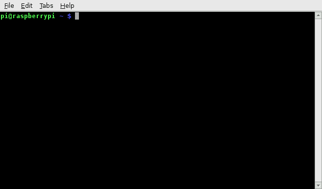

### 1.3.2. Login

**Accounts**

- There are be many user accounts on a Linux system
- Each account has a username and password for identification
- When you first start the machine you are prompted for username and password
- Default username is "pi", password is "raspberry"

**Man(ual) Pages**

- "man" gives information about a Linux command

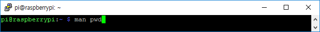

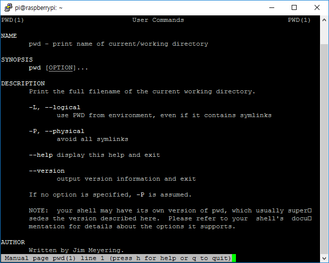

### 1.3.3. Linux Filesystem

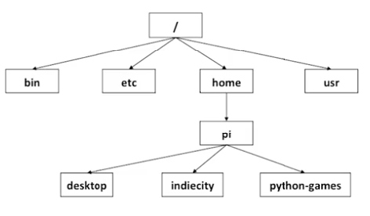

Hierarchy of directories and files

**pwd**

- Show current location

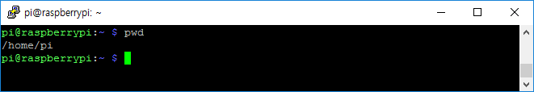

**cd**

- To a specific directory

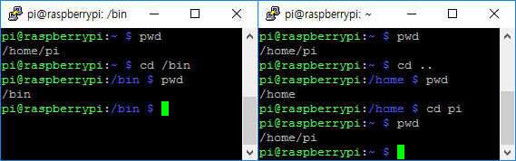

**ls**

- Show the contents of a diretory
  - Files and other directories
- Show all detail with -l option

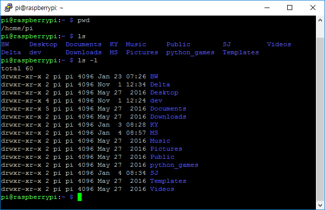

**mkdir, rmdir**

- mkdir creates a directory
- rmdir removes a directory
- rmdir only works if directory is empty

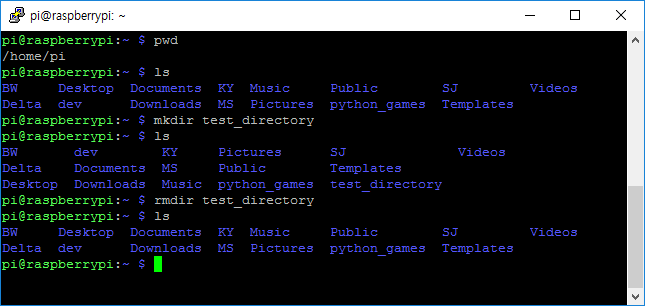

### 1.3.4. Text Editors

**nano**

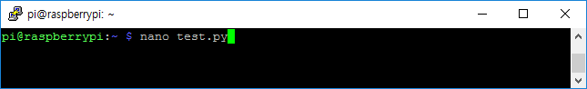

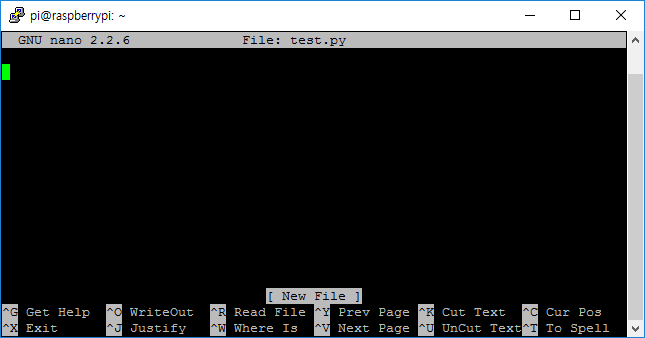

**Viewing a File**

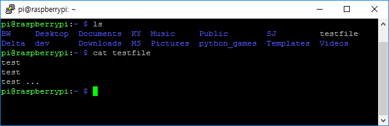

- "cat" prints the files to the terminal
- "head" prints the first 10 lines
- "last" prints the last 10 lines

**cp**

- Make a copy of a file
  - ex) cp origin.py duplicated.py

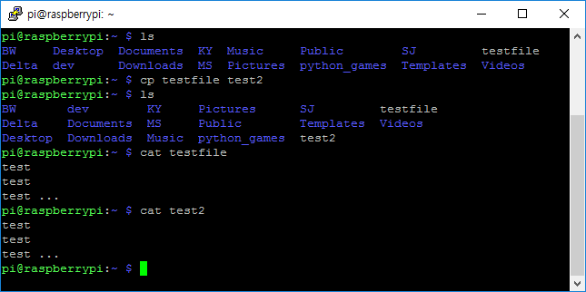

**mv**

- Move a file
- Rename it or move it to a new directory
  - ex) mv origin.py subdir/origin.py
  - ex) mv origin.py modified.py

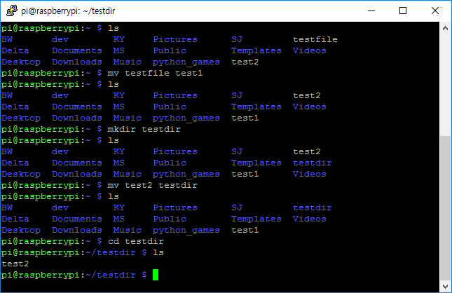

### 1.3.5. Permissions

**File Permissions**

- Files have owners
  - User who created the file
- Files have access permissions
  - Read (r), write (w), execute (x)
- Different permissions can be assigned according to type
  1. User: the file owner
  2. Group: a permission group
  3. Other: all users

**Viewing File Permissions**

- ls -l

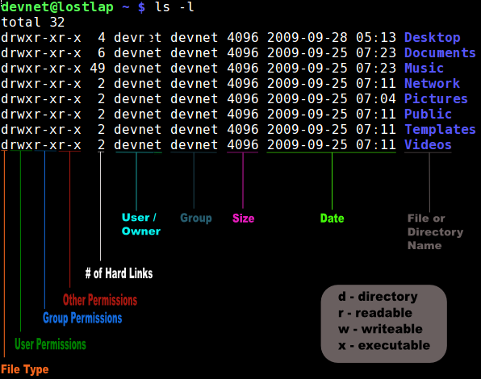

**Root Account**

- The root account has highest permission level
- Key files and directories are only accessible by root
- Sometimes you need root privileges
  - Install a program
  - Change the operating system
- Use the "sudo" command to gain root permission for a single command

### 1.3.6. Shutdown

- Should not just unplug a Linux machine
- Proper shutdown procedure is needed to place data
  - Flush all buffers, close files, etc.
- Use the "shutdown" command

# 2. Programming on Raspberry Pi

## 2.1. Python on Raspberry Pi

**Python Language**

- High-level language, easy to use
  - Do not need to explicitly declare data types
  - No pointers
  - Object-oriented programming, classes
- Slow compared to C, C++
  - Interpreted, not compiled
- Two versions : Python 2.x and Python 3.x
  - Python 2.x is still supported
  - Programming differences are small
  - Will use Python 3.x

**Run Python Code**

- Use VI editor to make Python code
- Run it by typing python3 in terminal
  - ex) python3 pyfile.py
  - ex) python3 (it runs python3 with typing and execute python code line by line)

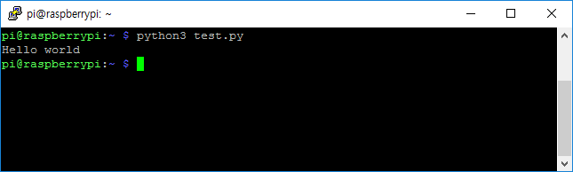

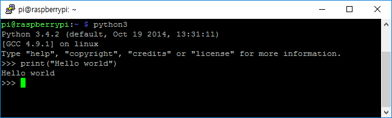

## 2.2. Basic of Python

- Learn Python easily at https://wikidocs.net/book/1, Jump to Python

### 2.2.1. Python Expression (Python 3)

**Algebraic Expressions**

- Python shell can evaluate algebraic expressions
- Many algebraic functions are available
  - abs()
  - min()
  - max()

    ```
    >>> 2 + 2
    4
    >>> 8 - 5
    3
    >>> 2*(3 + 2)
    10
    >>> 7/2
    3.5
    ```

**Boolean Expressions**

- Evaluate to True or False
- Often involve comparison operators <, >, ==, !=, <=, and >=

  ```
  >>> 2 < 4
  True
  >>> 1 > 3
  False
  >>> 2 == 4
  False
  >>> 2 != 3
  True
  >>> 1 <= 3
  True
  >>> 2 >= 4
  False
  ```

**Boolean Operators**

- Evaluate to True or False
- May include Boolean operators and, or, not

  ```
  >>> 2 < 3 and 3 < 4
  True
  >>> 4 == 5 and 3 < 4
  False
  >>> False and True
  False
  >>> Ture and True
  True
  >>> 4 == 5 or 3 < 4
  True
  >>> False or Ture
  True
  >>> False or False
  False
  >>> not(3 < 4)
  False
  ```

**Variables, Assignments**

- variable types are not declared
- Interpreter determines type by usage

  ```
  >>> x = 3
  >>> x
  3
  >>> 4 * x
  12
  >>> y = 4 * x
  >>> y
  12
  ```

### 2.2.2. Strings

**Strings**

- A sequence of characters enclosed in quotes 'Hello, world'
- Can be assigned to a variable
- Can be manipulated using string operators and functions

  ```
  >>> 'Hello, World'
  'Hello, World'
  >>> s = 'still'
  >>> t = 'life'
  ```

**String Operators**

| Operator | Definition |
| --- | --- |
| x in s | x is a substring of s |
| x not in s | x is not a substring of s |
| s + t | Concatenation of s and t |
| s *n, n* s | Concatenation of n copies of s |
| s[i] | Character at index i of s |
| len(s) | (function) Length of string s |

```
>>> 'Hello, World!'
'Hello, World!'
>>> s = 'still'
>>> t = 'life'
>>> s == 'still'
True
>>> s != t
True
>>> s < t
False
>>> s > t
True
```

**String Operator Examples**

```
>>> s = 'still'
>>> t = 'life'
>>> s + t
'stilllife'
>>> s + ' ' + t
'still life'
>>> 5 * s
'stillstillstillstillstill'
```

```
>>> 20 * '_'
'____________________'
>>> 'i' in s
True
>>> 'o' in t
False
>>> 'li' in t
True
>>> len(t)
4
```

**Indexing Operator**

- Index of an item in a sequence is its position in the sequence
- Indexing operator is [], takes an index as argument
- Indices start at 0
- Can be used to identify characters in a string

  ```
  >>> s = 'Apple'
  >>> s[0]
  'A'
  >>> s[1]
  'p'
  >>> s[4]
  'e'
  ```

### 2.2.3. Functions

- A sequence of instructions associated with a function name
- Function definition starts with def
- Followed by function name, open/close parentheses, and colon

  ```
  >>> def test():
            print ('A test function')
  >>> test()
  A test function
  >>>
  ```

### 2.2.4. Function Arguments

**Function Parameters/Arguments**

- A function can take arguments which are values bound to variables inside the function
- Arguments are listed between parenthesis in the function call

  ```
  >>> def circle_area(rad):
            print (3.14 * rad * rad)
  >>> circle_area(2)
  12.56
  ```

**Function Return Values**

- Functions can return values with the return instruction
- A function call is substituted for its return value in an expression

  ```
  >>> def circle_area(rad):
            return 3.14 * rad * rad
  >>> circle_area(2)
  12.56
  >>> 3 + circle_area(2)
  15.56
  ```

## 2.3. List & Control Flow

### 2.3.1. List

**Lists**

- A comma-separated sequence of items enclosed in square brackets
- Items can be numbers, strings, other lists, etc.

  ```
  >>> pets = ['ant', 'bat', 'cod', 'dog']
  >>> lst = [0, 1, 'two', [4, 'five']]
  >>> nums = [0, 1, 2, 3, 4, 5, 6, 7, 8]
  ```

**List Operators and Functions**

| Operator | Definition |
| --- | --- |
| x in lst | x is an item of lst |
| x not in lst | x is not an item of lst |
| lst + lstB | Concatenation of lst and lstB |
| lst*n, n*lst | Concatenation of n copies of lst |
| lst[i] | Item at index i of lst |
| len(lst) | Number of items in lst |
| min(lst) | Minimum item in lst |
| max(lst) | Maximum item in lst |
| sum(lst) | Sum of items in lst |

### 2.3.2. List Methods

**List Methods**

- List operators that are called on the list that they operate on

  ```
  >>> lst = [1, 2, 3]
  >>> lst.append(8)
  >>> lst
  ```

**List Methods**

| Method | Definition |
| --- | --- |
| lst.append(item) | adds item to the end of lst |
| lst.count(item) | returns the number of times item occurs in lst |
| lst.index(item) | Returns index of (first occurrence of) item in lst |
| lst.pop() | Removes and returns the last item in lst |
| lst.remove(item) | Removes (the first occurrence of) item from lst |
| lst.reverse(item) | Reverses the order of items in lst |
| lst.sort(item) | Sorts the items of lst in increasing order |

- append(), remove(), reverse(), and sort() do not return values

### 2.3.3. Control Flow

**Control Flow**

- Statements that change the order in which lines of code are executed :
  1. if statement

**If statement**

- Template:

  ```
  if <condition>:
        <indented code block>
  <non-indented statement>
  ```

- Example:

  ```
  if temp > 80:
        print ('It is hot!')
  print ('Goodbye.')
  ```

**If-else statement**

- Template:

  ```
  if <condition>:
        <indented code 1>
  else :
        <indented code 2>
  <non-indented statement>
  ```

- Example:

  ```
  if temp > 80:
        print ('hot!')
  else:
        print ('not hot.')
  print ('Goodbye.')
  ```

**For Loop**

- Executes a block of code for every element in a sequence

```
>>> name = 'Ian'
>>> for char in name:
            print(char)
I
a
n
>>>
```

**For Example**

- Any sequence can be used
- All code in loop must be indented

```
>>> for name in ['Jon', 'Mary', 'Pete']:
            print(name)
Jon
Mary
Pete
>>>
```

**While Loop**

- Execute indented block of code while condition is True

  ```
  >>> i = 0
  >>> while i < 3:
            print (i)
            i = i + 1
  0
  1
  2
  >>>
  ```

## 2.4. Exceptions

**Errors During Execution**

- Errors may happen when working with sockets
  - Socket cannot be opened
  - Data cannot be sent
- Errors occurring during execution are called Exceptions
- There are many kinds for each function
  - ZeroDivisionError
  - TypeError

**Handling Exceptions**

- When an error happens, you might want your code to do something appropriate
- Use try and except statements
- Place code with possible error inside the try clause
- Code in the except clause is executed when an exception occurs

  ```
  try:
        z = x / y
  except ZeroDivisionError:
        print("Divide by zero")
  ```

# 3. General Purpose IO pins

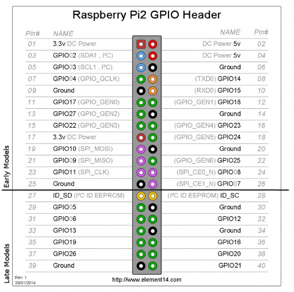

**import**

- Use Python3 Module which is already constucted
  - ex) `import RPi.GPIO as GPIO`

**Pin Direction and Assignment**

```
GPIO.setup(13, GPIO.OUT)
```

- Set the pin direction
- Like `pinMode(13, OUTPUT)` for Arduino

```
GPIO.output(13, True)
```

## 3.1. Blink an LED

```
import RPi.GPIO as GPIO
import time
GPIO.setmode(GPIO.BOARD)
GPIO.setup(13, GPIO.OUT)
while True:
    GPIO.output(13, True)
    time.sleep(1)
    GPIO.output(13, False)
    time.sleep(1)
```

[figure not shown]

## 3.2. Button

```
import RPi.GPIO as GPIO
import time
GPIO.setmode(GPIO.BOARD)
GPIO.setup(18, GPIO.IN)
while True:
    if GPIO.input(18) == 1:
        print("Button Pressed")
        time.sleep(0.5)
    else:
        print("Button Unpressed")
        time.sleep(0.5)
```

[figure not shown]

## 3.3. PWM on RPI

Pulse Width Modulation

- Duty cycle is the percent of time the pulse is high
- Increasing duty cycle increases perceived voltage

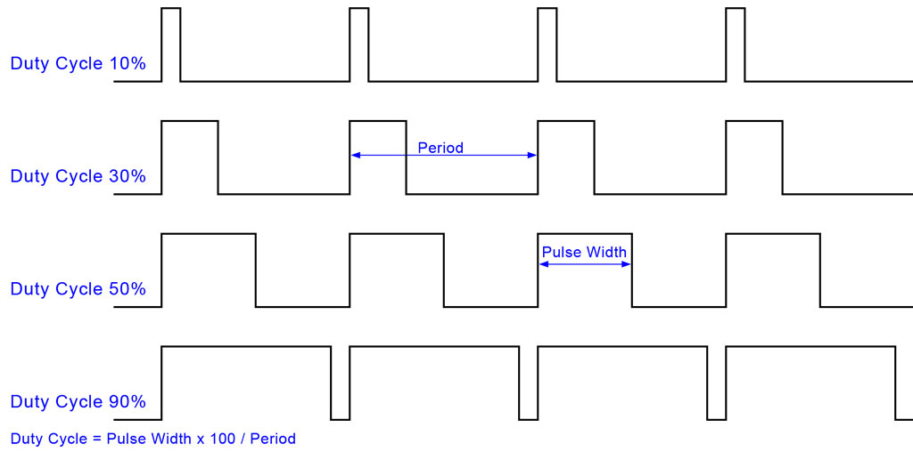

- PWM functions in GPIO library

**PWM initialization**

```
pwm_obj = GPIO.PWM(18, 400)
```

```
- Mark pin for PWM
- Second argument is frequency
```

```
pwm_obj.start(100)
```

```
- Start generating PWM signal
- Argument is duty cycle, 0 to 100
```

**PWM Control**

```
pwm_obj.ChangeDutyCycle(50)
```

- Assign new duty cycle
- PWM frequency is not accurate
  - Off by over 50% at 10kHz

**Frequency Control**

- Cannot easily control frequency
  - No tone() function as on Arduino -Need to do it manually

```
while True:
    GPIO.output(18, True)
    time.sleep(0.5)
    GPIO.output(18, False)
    time.sleep(0.5)
```

- 1Hz frequency

**PWM Example**

```
import RPi.GPIO as GPIO
import time
GPIO.setmode(GPIO.BOARD)
GPIO.setup(13, GPIO.OUT)

pwm = GPIO.PWM(13, 50)
pwm.start(0)
for i in range(100):
    pwm.ChangeDutyCycle(i)
    time.sleep(0.1)
for i in range(100, 0, -1):
    pwm.ChangeDutyCycle(i)
    time.sleep(0.5)
```

[figure not shown]

## 3.4. DC Motor

```
import RPi.GPIO as GPIO
import time
GPIO.setmode(GPIO.BOARD)
GPIO.setup(13, GPIO.OUT)

pwm = GPIO.PWM(13, 50)
pwm.start(0)
for i in range(100):
    pwm.ChangeDutyCycle(i)
    time.sleep(0.1)
for i in range(100, 0, -1):
    pwm.ChangeDutyCycle(i)
    time.sleep(0.5)
```

[figure not shown]

## 3.5. Servo Motor Control

[figure not shown]

**Servo Motors**

- Motors whose rotation angle can be precisely controlled
- Pulse width controls rotation anlge
  - 50Hz frequency is normal
  - 1.0 ms width = 0 degrees
  - 2.0 ms width = 180 degrees

**Servo Control**

Servo Motor Wiring

- Three wires:
  - Power (Red)
  - Ground (Black)
  - Signal (White or Yellow)
- PWM applied to signal wire
- Power should supply sufficient current

Servo Motor Power

- External power supply should be used
  - ~5 Volts
- Raspberry Pi cannot supply enough current to drive typical motors
  - ~1 Amp
- External supply has power and ground wires
  - Wire external power wire to Servo power wire
  - External ground wired to Raspberry Pi ground

**Servo Example 1**

```
import RPi.GPIO as GPIO

GPIO.setmode(GPIO.BOARD)
GPIO.setup(12, GPIO.OUT)
pwm = GPIO.PWM(12, 50)
pwm.start(0)
for i in range(100)
    pwm.ChangeDutyCycle(i)
    print(i)
    time.sleep(0.5)
for i in range(100, 0, -1):
    pwm.ChangeDutyCycle(i)
    print(i)
    time.sleep(0.5)
```

**Servo Example 2**

```
import RPi.GPIO as GPIO
import numpy as np
import time
GPIO.setmode(GPIO.BOARD)
GPIO.setup(8, GPIO.OUT)

pwm = GPIO.PWM(8, 50)
pwm.start(0)

while True:
    for i in np.arange(2.5, 12.5, 0.1):
        pwm.ChangeDutyCycle(i)
        time.sleep(0.1)
    for i in np.arange(12.5, 2.5,-0.1):
        pwm.ChangeDutyCycle(i)
        time.sleep(0.1)
```

[figure not shown]

# 4. Advanced

## 4.1. I2C Communication

- Set Raspberry Pi to activate I2C communication as [follows](https://learn.adafruit.com/adafruits-raspberry-pi-lesson-4-gpio-setup/configuring-i2c)

```
#!/usr/bin/python

import smbus
import math
import time
import os

# Power management registers

power_mgmt_1 = 0x6b
power_mgmt_2 = 0x6c

def read_byte(adr):
    return bus.read_byte_data(address, adr)

def read_word(adr):
    high = bus.read_byte_data(address, adr)
    low = bus.read_byte_data(address, adr+1)
    val = (high << 8) + low
    return val

def read_word_2c(adr):
    val = read_word(adr)
    if (val >= 0x8000):
        return -((65535 - val) + 1)
    else:
        return val

def dist(a,b):
    return math.sqrt((a*a)+(b*b))

def get_y_rotation(x,y,z):
    radians = math.atan2(x, dist(y,z))
    return -math.degrees(radians)

def get_x_rotation(x,y,z):
    radians = math.atan2(y, dist(x,z))
    return math.degrees(radians)

bus = smbus.SMBus(1) # or bus = smbus.SMBus(1) for Revision 2 boards
address = 0x68       # This is the address value read via the i2cdetect command

# Now wake the 6050 up as it starts in sleep mode

bus.write_byte_data(address, power_mgmt_1, 0)

while True:
    os.system('cls' if os.name == 'nt' else 'clear')

    print("gyro data")
    print("---------")

    gyro_xout = read_word_2c(0x43)
    gyro_yout = read_word_2c(0x45)
    gyro_zout = read_word_2c(0x47)

    print("gyro_xout: ", gyro_xout)
    print("scaled   : ", (gyro_xout / 131))
    print("gyro_yout: ", gyro_yout)
    print("scaled   : ", (gyro_yout / 131))
    print("gyro_zout: ", gyro_zout)
    print("scaled   : ", (gyro_zout / 131))
    print()
    print("accelerometer data")
    print("------------------")

    accel_xout = read_word_2c(0x3b)
    accel_yout = read_word_2c(0x3d)
    accel_zout = read_word_2c(0x3f)

    accel_xout_scaled = accel_xout / 16384.0
    accel_yout_scaled = accel_yout / 16384.0
    accel_zout_scaled = accel_zout / 16384.0

    print("accel_xout: ", accel_xout)
    print("scaled    : ", accel_xout_scaled)
    print("accel_yout: ", accel_yout)
    print("scaled    : ", accel_yout_scaled)
    print("accel_zout: ", accel_zout)
    print("scaled    : ", accel_zout_scaled)
    print()
    print("x rotation: " , get_x_rotation(accel_xout_scaled, accel_yout_scaled, accel_zout_scaled))
    print("y rotation: " , get_y_rotation(accel_xout_scaled, accel_yout_scaled, accel_zout_scaled))

    time.sleep(0.5)
```

[figure not shown]

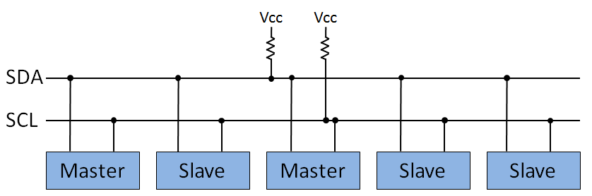

## 4.2. AD Converter

- Set Raspberry Pi to activate SPI communication as [follows](https://learn.adafruit.com/raspberry-pi-analog-to-digital-converters/mcp3008)

```
# Simple example of reading the MCP3008 analog input channels and printing
# them all out.
# Author: Tony DiCola
# License: Public Domain
import time

# Import SPI library (for hardware SPI) and MCP3008 library.
import Adafruit_GPIO.SPI as SPI
import Adafruit_MCP3008


# Software SPI configuration:
CLK  = 18
MISO = 23
MOSI = 24
CS   = 25
mcp = Adafruit_MCP3008.MCP3008(clk=CLK, cs=CS, miso=MISO, mosi=MOSI)

# Hardware SPI configuration:
# SPI_PORT   = 0
# SPI_DEVICE = 0
# mcp = Adafruit_MCP3008.MCP3008(spi=SPI.SpiDev(SPI_PORT, SPI_DEVICE))


print('Reading MCP3008 values, press Ctrl-C to quit...')
# Print nice channel column headers.
print('| {0:>4} | {1:>4} | {2:>4} | {3:>4} | {4:>4} | {5:>4} | {6:>4} | {7:>4} |'.format(*range(8)))
print('-' * 57)
# Main program loop.
while True:
    # Read all the ADC channel values in a list.
    values = [0]*8
    for i in range(0, 3):
        # The read_adc function will get the value of the specified channel (0-3).
        values[i] = mcp.read_adc(i)
    # Print the ADC values.
    print('| {0:>4} | {1:>4} | {2:>4} | {3:>4} | {4:>4} | {5:>4} | {6:>4} | {7:>4} |'.format(*values))
    # Pause for half a second.
    time.sleep(0.1)
```

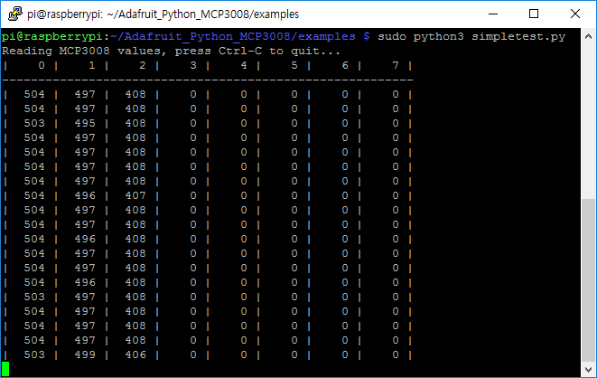

## 4.3. Threading

```
import threading
import time

def every_second(msg):
    i = 0
    while True:
        time.sleep(1)
        i += 1
        print(msg, i)

def every_five_second(msg):
    i = 0
    while True:
        time.sleep(5)
        i += 5
        print(msg, i)

t1 = threading.Thread(target = every_second, args = ("t1 :",))
t2 = threading.Thread(target = every_five_second, args = ("t2 :",))
t1.daemon = True
t2.daemon = True
t1.start()
t2.start()

while True:
    pass
```

## 4.4. Camera

[figure not shown]

### 4.4.1. Camera Module

Raspberry Pi Camera Module

- Cameras are useful sensors
- There are many cameras that can be used with Raspberry Pis(USB)
- The Raspberry Pi Camera module is useful
  - Camera serial Interface (CSI) to the processor
- Good Libraries for control

Enabling the Camera

- Use `raspi-config` to enable the CSI interface `sudo raspi-config`
- Select Enable Camera, Finish

### 4.4.2. Picamera Library

python-picamera Library

- Install the library

  ```
  sudo apt-get updata
  sudo apt-get install python3picamera
  picamera
  ```

- Using the librarty

  ```
  import picamera
  ```

- Instantiate an object of the PiCamera class

  ```
  camera = picamera.PiCamera()
  ```

Camera Functions

- Take a picture

  ```
  camera.capture("pict.jpg")
  ```

- Changing camera settings
  - There are many

    ```
    camera.hflip = True
    camera.vflip = True
    camera.brightness = 50
    camera.sharpness = 0
    ```

- View vido on RPi screen

  ```
  camera.start_preview()
  camera.stop_preview()
  ```

Video Recording

```
import picamera
import time

camera.start_recording("vid.h264")
time.sleep(10)
camera.stop_recording()
```

### 4.4.3. Capturing Images

Sending an Image on the Network

- What if you want to a remote site?
  - Home security system
- Capture an image, send it on a connection

```
mysocket = socket.socket()
mysocket.connect(('aserver', 8000))
conn = mysocket.makefile('wb')
camera.capture(conn, 'jpeg')
```

- Need a file-like object to capture to

Timelapse Photography

- camera.capture_continuous() takes photos over time
- Takes one argument, a file name
- {counter} and {timestamp} can be substituted
- ex."picture{counter}.jpg" produces picture1.jpg, picture2.jpg, etc.

Continuous Capture

```
camera = picamera.PiCamera()
for filename in camera.capture_continuous('img(counter).jpg'):
        time.sleep(300)
```

- Iterate through all images
  - Infinite loop
- 5 minute delay between images

**Example**

```
import picamera
camera = picamera.PiCamera()
camera.capture('test_image.jpg')
```

```python
%%javascript
$.getScript('https://kmahelona.github.io/ipython_notebook_goodies/ipython_notebook_toc.js')
```